# IISER Advanced Bioacoustics Workshop - Occupancy Modelling

Spencer R. Keyser

K. Lisa Yang Center for Conservation Bioacoustics, Cornell Lab of Ornithology, Cornell University

2026-01-23

## Package Loading

```
## here() starts at C:/Users/srk252/Documents/Rprojs/IISER_YC_AdvancedBioacoustics
```

## Data loading and preparation

First thing we want to do is load in our data from *Occ_Data_Prep.R*. The data should be in the subdirectory *./Modules/Occ_Abund/Data/Occ_Data/*.

```r
## Set seed for consistency
set.seed(108)

## We saved the data as an RDS file type
occ.dat <- readRDS(here("./Modules/Occ_Abund/Data/Occ_Data/UnmarkedData_SpeciesThresh_975minMaxPrex_NewVars.rds"))

## Structure of the object
str(occ.dat)
```

```
## List of 3
##  $ y       : num [1:86, 1:1625, 1:5] 0 1 0 0 0 0 0 0 0 0 ...
##   ..- attr(*, "dimnames")=List of 3
##   .. ..$ species: chr [1:86] "Acorn Woodpecker" "American Robin" "Ash-throated Flycatcher" "Band-tailed Pigeon" ...
##   .. ..$ sites  : chr [1:1625] "C2065_U1" "C2134_U2" "C2203_U2" "C4178_U2" ...
##   .. ..$ reps   : chr [1:5] "Rep_1" "Rep_2" "Rep_3" "Rep_4" ...
##  $ obsCovs :List of 2
##   ..$ eff.hrs : num [1:1625, 1:5] 42 42 42 NA NA NA NA NA NA NA ...
##   .. ..- attr(*, "dimnames")=List of 2
##   .. .. ..$ : NULL
##   .. .. ..$ : NULL
##   ..$ eff.jday: num [1:1625, 1:5] 154 154 154 NA NA ...
##   .. ..- attr(*, "dimnames")=List of 2
##   .. .. ..$ : NULL
##   .. .. ..$ : NULL
##  $ siteCovs:'data.frame':    1625 obs. of  24 variables:
##   ..$ Cell_Unit              : chr [1:1625] "C2065_U1" "C2134_U2" "C2203_U2" "C4178_U2" ...
##   ..$ utme                   : int [1:1625] 680181 680143 679573 750820 753990 754461 757910 757538 752914 751779 ...
##   ..$ utmn                   : int [1:1625] 4376551 4373087 4367622 4240072 4238522 4238877 4238556 4239408 4236095 4235855 ...
##   ..$ X                      : num [1:1625] -121 -121 -121 -120 -120 ...
##   ..$ Y                      : num [1:1625] 39.5 39.5 39.4 38.3 38.3 ...
##   ..$ topo_elev              : int [1:1625] 1444 1489 1171 1754 1725 1767 1694 1659 1743 1713 ...
##   ..$ topo_tpi               : num [1:1625] 0.0842 0.0296 0.0502 0.0356 -0.1437 ...
##   ..$ tmx_bcm_mn             : num [1:1625] 18.4 17.5 18.8 16 16.2 ...
##   ..$ ppt_bcm_mn             : num [1:1625] 1684 1774 1684 1223 1210 ...
##   ..$ fire1_5yr_cbi_mn       : num [1:1625] 0 0 0 0 0 0 0 0 0 0 ...
##   ..$ fire6_10yr_cbi_mn      : num [1:1625] 0 0 0 0 0 ...
##   ..$ fire11_35yr_cbi_mn     : num [1:1625] 0 0 0 0 0 ...
##   ..$ fire1_5yr_high_prop    : num [1:1625] 0 0 0 0 0 0 0 0 0 0 ...
##   ..$ fire1_5yr_lowmod_prop  : num [1:1625] 0 0 0 0 0 0 0 0 0 0 ...
##   ..$ fire6_10yr_high_prop   : num [1:1625] 0 0 0 0 0 0 0 0 0 0 ...
##   ..$ fire6_10yr_lowmod_prop : num [1:1625] 0 0 0 0 0 ...
##   ..$ fire11_35yr_high_prop  : num [1:1625] 0 0 0 0 0 ...
##   ..$ fire11_35yr_lowmod_prop: num [1:1625] 0 0 0 0 0 ...
##   ..$ standage_f3_mn         : num [1:1625] 105.6 87.9 97.2 98.8 100.2 ...
##   ..$ cpycovr_f3_mn          : num [1:1625] 74 60.7 72.2 59.6 61.6 ...
##   ..$ ch_cfo_mn              : num [1:1625] 27.6 13.6 26.6 11.3 20 ...
##   ..$ ch_cfo_sd              : num [1:1625] 4.85 4.3 7.43 6.91 7.31 ...
##   ..$ cc_cfo_mn              : num [1:1625] 81.5 50 76.5 43.2 60.9 ...
##   ..$ cc_cfo_sd              : num [1:1625] 6.7 12.7 12.3 18.8 13.6 ...
```

```r
## Check the dimensions of our observation data
dim(occ.dat$y)
```

```
## [1]   86 1625    5
```

```r
head(occ.dat$y[1,,])
```

```
##           reps
## sites      Rep_1 Rep_2 Rep_3 Rep_4 Rep_5
##   C2065_U1     0     0     0    NA    NA
##   C2134_U2     0     0     0    NA    NA
##   C2203_U2     0     0     0     0    NA
##   C4178_U2    NA     0     0     0     0
##   C4179_U1    NA     0     0     0     0
##   C4179_U2    NA     0     0     0     0
```

We see that our detection/non-detection data `y` is a 3-dimensional array with 86 species, 1625 sites, and 5 sampling events. `str(occ.dat)` further shows the full object contains: 1. `y`: Detection/non-detection data. 1. A list of two data frames for two survey-level covariates `eff.hrs` and `eff.jday` which are the sum of listening hours per unit per 6-day collapsed sampling period and the mean ordinal date of the 6-day period, respectively. 1. A data frame of site-level covariates.

The first thing we want to do is reorient the array of capture histories to move species to the third dimension (this is purely for convenience).

```r
occ.dat$y <- aperm(occ.dat$y, c(2,3,1))
```

```r
## To reduce the amount of data let's subset to 500 random locations with a minimum of 1km between points
siteCovs <- occ.dat$siteCovs
siteCovs$Cell <- as.factor(gsub("_U\\d{1}", "", siteCovs$Cell_Unit))
coords <- siteCovs |>
  sf::st_as_sf(coords = c("X", "Y"), crs = 4326)

## Subsample
spsub <- spatialEco::subsample.distance(coords, size = 500, d = 1000)
siteCovs <- spsub
subARU <- as.numeric(rownames(siteCovs))

## Break the data apart for demonstration purposes
y <- occ.dat$y
obsCovs <- occ.dat$obsCovs

## Subsampled sites
y <- y[subARU,,]
y.all <- y

## Subsample the observation-level covariates
obsCovs <- lapply(obsCovs, FUN = function(x) x[subARU,])

## Confirm we have the right sites
all(which(is.na(y[,,1])) == which(is.na(obsCovs$eff.hrs)))
```

```
## [1] TRUE
```

For the rest of the tutorial on we will be looking at occupancy patterns and responses for the Mountain quail (*Oreortyx pictus*). Mountain quail are a montane species native to western North America inhabiting shrub-dominated ecosystems that cover a broad range of elevations. Despite being ubiquitously distributed throughout nearly every major mountain range in the western US they are a secretive species. Bioacoustics is a great way to get better estimates of this species habitat associations, distribution, and population dynamics (see Brunk et al. (2023))!

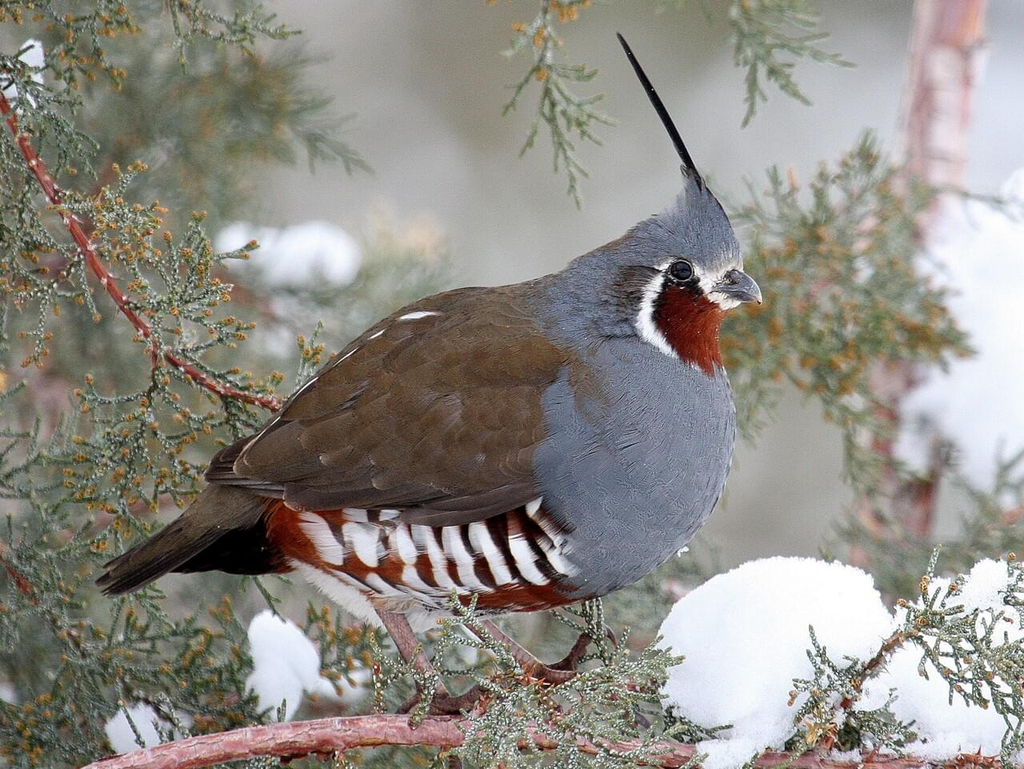

```r
# Take one species since we are doing a single species model
## Let's focus on Hermit warbler
sp.ind <- which(dimnames(y)[[3]] == "Mountain Quail")
y <- y[,,sp.ind]

## Remove the spatial features of the siteCovs
siteCovs <- sf::st_drop_geometry(siteCovs)
all(rownames(y) == siteCovs$Cell_Unit)
```

```
## [1] TRUE
```

We now have three subsetted objects that will be used for our occupancy models. Let’s take a look!

```r
str(y)
```

```
##  num [1:500, 1:5] 1 NA 1 1 0 1 NA 0 1 0 ...
##  - attr(*, "dimnames")=List of 2
##   ..$ sites: chr [1:500] "C0165_U1" "C6110_U1" "C6385_U1" "C0281_U1" ...
##   ..$ reps : chr [1:5] "Rep_1" "Rep_2" "Rep_3" "Rep_4" ...
```

```r
str(siteCovs)
```

```
## 'data.frame':    500 obs. of  23 variables:
##  $ Cell_Unit              : chr  "C0165_U1" "C6110_U1" "C6385_U1" "C0281_U1" ...
##  $ utme                   : int  646758 297647 294762 634775 743395 744342 739094 337962 661216 634854 ...
##  $ utmn                   : int  4402029 4118013 4102745 4492973 4290833 4293836 4217591 4057369 4447193 4419668 ...
##  $ topo_elev              : int  1226 1467 1450 1846 1949 2101 1151 2062 1500 1360 ...
##  $ topo_tpi               : num  0.0631 0.0573 -0.0108 -0.119 0.018 ...
##  $ tmx_bcm_mn             : num  18.6 18.4 18.2 14 14.9 ...
##  $ ppt_bcm_mn             : num  2060 853 843 1059 1264 ...
##  $ fire1_5yr_cbi_mn       : num  2.68 2.96 1.87 0 0 ...
##  $ fire6_10yr_cbi_mn      : num  0 0 0 1.71 0 ...
##  $ fire11_35yr_cbi_mn     : num  0 0 0 0 0 ...
##  $ fire1_5yr_high_prop    : num  0.985 1 0.338 0 0 ...
##  $ fire1_5yr_lowmod_prop  : num  0.0152 0 0.6 0 0 ...
##  $ fire6_10yr_high_prop   : num  0 0 0 0.215 0 ...
##  $ fire6_10yr_lowmod_prop : num  0 0 0 0.785 0 ...
##  $ fire11_35yr_high_prop  : num  0 0 0 0 0 0 0 0 0 0 ...
##  $ fire11_35yr_lowmod_prop: num  0 0 0 0 0 ...
##  $ standage_f3_mn         : num  83.3 132.6 80.3 78.8 130.7 ...
##  $ cpycovr_f3_mn          : num  64.3 67.5 64 29.6 49.5 ...
##  $ ch_cfo_mn              : num  12.65 9.13 11.35 7.65 17.85 ...
##  $ ch_cfo_sd              : num  10.54 4.21 7.49 6.46 5.27 ...
##  $ cc_cfo_mn              : num  50.3 44.7 41.3 25.8 56.3 ...
##  $ cc_cfo_sd              : num  28.6 11.4 16 18.1 13.2 ...
##  $ Cell                   : Factor w/ 845 levels "C0001","C0002",..: 110 704 725 198 447 444 544 775 48 216 ...
```

```r
str(obsCovs)
```

```
## List of 2
##  $ eff.hrs : num [1:500, 1:5] 42 NA 16 23 23 30 NA 42 42 42 ...
##   ..- attr(*, "dimnames")=List of 2
##   .. ..$ : NULL
##   .. ..$ : NULL
##  $ eff.jday: num [1:500, 1:5] 154 NA 154 154 154 ...
##   ..- attr(*, "dimnames")=List of 2
##   .. ..$ : NULL
##   .. ..$ : NULL
```

Next, we package the data up in the format that `unmarked` (Fiske and Chandler 2011, Kellner et al. 2023) uses with the function `unmarkedFrameOccu`. It’s worth noting that `unmarked` has a variety of `unmarkedFrame` objects with various extensions meant to package data for the model you expect to run! For example, later on we will see how to package data for a false-positive occupancy model using `unmarkedFrameOccuFP` and for a multi-species occupancy model with `unmarkedFrameOccuComm`.

```r
## Package these elements into an unmarked object
unmk <- unmarkedFrameOccu(y = y, siteCovs = siteCovs, obsCovs = obsCovs)
class(unmk)
```

```
## [1] "unmarkedFrameOccu"
## attr(,"package")
## [1] "unmarked"
```

```r
summary(unmk)
```

```
## unmarkedFrame Object
##
## 500 sites
## Maximum number of observations per site: 5
## Mean number of observations per site: 4.15
## Sites with at least one detection: 211
##
## Tabulation of y observations:
##    0    1 <NA>
## 1501  576  423
##
## Site-level covariates:
##     Cell_Unit        utme             utmn           topo_elev
##  C0001_U3:  1   Min.   :236380   Min.   :3916783   Min.   : 343
##  C0004_U2:  1   1st Qu.:324703   1st Qu.:4150508   1st Qu.:1343
##  C0006_U2:  1   Median :653832   Median :4308760   Median :1650
##  C0011_U3:  1   Mean   :549335   Mean   :4278410   Mean   :1639
##  C0012_U1:  1   3rd Qu.:699119   3rd Qu.:4406986   3rd Qu.:1942
##  C0027_U2:  1   Max.   :763607   Max.   :4522081   Max.   :2865
##  (Other) :494
##     topo_tpi            tmx_bcm_mn      ppt_bcm_mn     fire1_5yr_cbi_mn
##  Min.   :-0.3153539   Min.   :10.50   Min.   : 322.4   Min.   :0.0000
##  1st Qu.:-0.0330124   1st Qu.:14.54   1st Qu.:1013.0   1st Qu.:0.0000
##  Median : 0.0001365   Median :16.09   Median :1192.8   Median :0.0000
##  Mean   : 0.0045990   Mean   :16.41   Mean   :1291.0   Mean   :0.2615
##  3rd Qu.: 0.0439829   3rd Qu.:18.28   3rd Qu.:1599.7   3rd Qu.:0.0000
##  Max.   : 0.2332589   Max.   :24.79   Max.   :2537.9   Max.   :2.9657
##
##  fire6_10yr_cbi_mn fire11_35yr_cbi_mn fire1_5yr_high_prop fire1_5yr_lowmod_prop
##  Min.   :0.0000    Min.   :0.0000     Min.   :0.00000     Min.   :0.00000
##  1st Qu.:0.0000    1st Qu.:0.0000     1st Qu.:0.00000     1st Qu.:0.00000
##  Median :0.0000    Median :0.0000     Median :0.00000     Median :0.00000
##  Mean   :0.2094    Mean   :0.1832     Mean   :0.06417     Mean   :0.06471
##  3rd Qu.:0.0000    3rd Qu.:0.0000     3rd Qu.:0.00000     3rd Qu.:0.00000
##  Max.   :2.7900    Max.   :2.7388     Max.   :1.00000     Max.   :1.00000
##
##  fire6_10yr_high_prop fire6_10yr_lowmod_prop fire11_35yr_high_prop
##  Min.   :0.00000      Min.   :0.000          Min.   :0.00000
##  1st Qu.:0.00000      1st Qu.:0.000          1st Qu.:0.00000
##  Median :0.00000      Median :0.000          Median :0.00000
```

[output cut: 15 more lines]

```
##  Median : 6.0434   Median :50.362   Median :13.779   C0135  :  2
##  Mean   : 6.0835   Mean   :51.309   Mean   :14.075   C0165  :  2
##  3rd Qu.: 7.2266   3rd Qu.:61.616   3rd Qu.:15.984   C0201  :  2
##  Max.   :13.0470   Max.   :90.217   Max.   :28.678   C0229  :  2
##                                                      (Other):488
##
## Observation-level covariates:
##     eff.hrs         eff.jday
##  Min.   : 2.00   Min.   :154.5
##  1st Qu.:42.00   1st Qu.:160.5
##  Median :42.00   Median :166.5
##  Mean   :38.39   Mean   :165.8
##  3rd Qu.:42.00   3rd Qu.:172.5
##  Max.   :42.00   Max.   :178.5
##  NA's   :423     NA's   :423
```

We can inspect the output from the new unmarked dataframe.

## Model Fitting

Fitting an occupancy model with `unmarked` is quite easy. You can specify the fomula using the standard linear model syntax in R. Recall from our lecture the basic structure of the occupancy model is
$$State \space Process: z_{i} \sim Bernoulli(\psi)\\
Observation \space Process: y_{ij}|z_i \sim Bernoulli(z_i * p_{ij})$$
In the simplest case we define the model as an intercept only model such that detection and occupancy do not vary as a function of any covariates. We denote this in the following code as `~1 ~1`, where the first component is the detection model and the second is the occupancy component in `unmarked`.
$$logit(\psi_i) = \beta_0\\
logit(p_{ij}) = \alpha_0$$

```r
## Start with the simplest possible model (i.e., a null model)
fm1 <- occu(~1 ~1, data = unmk)
```

Next, we explore the results from this model fit `fm1`, what do you see?

```r
## Take a minute to look at these values...what do they mean?
summary(fm1)
```

```
##
## Call:
## occu(formula = ~1 ~ 1, data = unmk)
##
## Occupancy (logit-scale):
##  Estimate     SE    z P(>|z|)
##    -0.252 0.0933 -2.7  0.0069
##
## Detection (logit-scale):
##  Estimate     SE    z  P(>|z|)
##     0.441 0.0716 6.16 7.49e-10
##
## AIC: 1892.664
## Number of sites: 500
```

The output simply reflects the mean estimated occupancy and detection probabilities, respectively. It also provides the standard error, z-scores, and significance. It’s important to note that these values on on the logit scale. To transform them to probability scale we can use the inverse logit transformation. Mathematically, this is expressed as $p = \frac{e^p}{1+e^p}$. We can get these transformed values using the `plogis` function in R. We can then plug these values into this function to get occupancy and detection probabilities.

```r
## We can manually back-transform from logit to probability scale
## or using the plogis() function
inv_logit <- function(x){
  val <- (exp(x))/(1+exp(x))
  return(val)
}

## For example...
plogis(0.5) == inv_logit(0.5)
```

```
## [1] TRUE
```

```r
## Occupancy probability for this species is...
occ.p <- plogis(coef(fm1)[1])

## Detection probability for this species is...
det.p <- plogis(coef(fm1)[2])

## Probs
null.dat <- data.frame(DetProb = round(det.p, 2),
                       OccProb = round(occ.p, 2))

## Table
knitr::kable(null.dat,
             col.names = c("Detection Prob.", "Occupancy Prob."),
             row.names = NA)
```

|  | Detection Prob. | Occupancy Prob. |
| --- | --- | --- |
| p(Int) | 0.61 | 0.44 |

For convenience, you can also use the predict function with `type = "state"` for occupancy and `type = "det"` for detection.

```r
## We can get these value transformed returned from unmarked itself with 95% CIs
predict(fm1, type = "state")[1,]
```

```
##   Predicted        SE     lower     upper
## 1 0.4373139 0.0229576 0.3929499 0.4827038
```

```r
predict(fm1, type = "det")[1,]
```

```
##   Predicted         SE     lower     upper
## 1 0.6085051 0.01706876 0.5745898 0.6414039
```

## Adding complexity: Covariates for detection

Next, we add in some further complexity but assuming that our probability of detecting a species depends on some survey-level covariates: the number of hours spent recording and the day the recordings were made on. This can be represented as $logit(p_{ij}) = \alpha_0 + \alpha_1 * Effort \space Hours_{ij} + \alpha_2 * Ordinal \space Date_{ij}$. As a note, we center and scale the predictors prior to model fitting for ease of interpretation. The interpretation of the intercept of the model for $p$ is now assuming $logit(p_{ij}) = \alpha_0 + \alpha_1 * 0 + \alpha_2 * 0$, such that the intercept is interpreted when all covariates are at their mean. Note: Because we `scaled` predictors internally we provide the `newdata` argument with data on the natural scale of the predictors rather than `scaled` values because `unmarked` handles the back-transformations internally for us.

```r
## ~~~~~~~~~~~~~~~~~~~~~~~~~~~~~~~~~~~~~~~~~~~~~~~~~~~~~~~~~~~~~
##
## Subsection: Detection covariates
##
## ~~~~~~~~~~~~~~~~~~~~~~~~~~~~~~~~~~~~~~~~~~~~~~~~~~~~~~~~~~~~~
fm2 <- occu(~ scale(eff.hrs) + scale(eff.jday) ~1, data = unmk)

## Before we were able to directly estimate backtransformed detection and
## occupancy because they were not a function of covariates...now we have
## to select some values since we have a detection model with covariates

## occupancy - note we didn't use covariates in this part of the model!!
predict(fm2, type = "state")[1,]
```

```
##   Predicted         SE     lower     upper
## 1 0.4325757 0.02265099 0.3888332 0.4773953
```

```r
## Let's see how detection responds to varying the ordinal date
## Let's hold effort hours at the mean value
eff.hrs.mean <- mean(obsCovs$eff.hrs, na.rm = T)

## Next we vary ordinal date by 1 day across the range of the predictor
eff.jday.seq <- seq(min(obsCovs$eff.jday, na.rm = T), max(obsCovs$eff.jday, na.rm = T), by = 1)

## Bundle this up into a prediction df
nd <- data.frame(eff.hrs = eff.hrs.mean, eff.jday = eff.jday.seq)

## Predict detection probability as a function of this new data
nd.pred <- round(predict(fm2, type = "det", newdata = nd, appendData = TRUE), 2)
head(nd.pred)
```

```
##   Predicted   SE lower upper eff.hrs eff.jday
## 1      0.88 0.02  0.85  0.91   38.39    154.5
## 2      0.87 0.02  0.83  0.90   38.39    155.5
## 3      0.86 0.02  0.82  0.89   38.39    156.5
## 4      0.84 0.02  0.80  0.87   38.39    157.5
## 5      0.82 0.02  0.78  0.85   38.39    158.5
## 6      0.80 0.02  0.76  0.84   38.39    159.5
```

```r
tail(nd.pred)
```

```
##    Predicted   SE lower upper eff.hrs eff.jday
## 20      0.40 0.02  0.36  0.45   38.39    173.5
## 21      0.37 0.02  0.32  0.42   38.39    174.5
## 22      0.34 0.03  0.29  0.39   38.39    175.5
## 23      0.31 0.03  0.26  0.37   38.39    176.5
## 24      0.29 0.03  0.24  0.34   38.39    177.5
## 25      0.26 0.03  0.21  0.32   38.39    178.5
```

```r
## We can get confidence intervals for parameter estimates via confint
confint(fm2, type = "det")
```

```
##                          0.025      0.975
## p(Int)              0.42185455  0.7415944
## p(scale(eff.hrs))   0.05718433  0.3838961
## p(scale(eff.jday)) -1.19270942 -0.8654735
```

## Adding Complexity: Covariates for both detection and occupancy

Next, we will build in some variables to model occupancy probability and keep our detection model structure from above.
$$State \space Process: z_i \sim Bernoulli(\psi_i) \\
logit(\psi_i) = \beta_0 + \beta_nX_n \\
Observation \space Process: y_{ij}|z_i \sim Bernoulli(z_ip_{ij}) \\
logit(p_{ij}) = alpha_0 + \alpha_NX_n$$
For this example, we will examine the influence of elevation on species occupancy. The structure of the model is very similar to above but we have added in `scale(topo_elev)` to the state process piece of the formula. We can repeat the steps above to look at this new model.

```r
## ~~~~~~~~~~~~~~~~~~~~~~~~~~~~~~~~~~~~~~~~~~~~~~~~~~~~~~~~~~~~~
##
## Subsection: Add some occupancy covariates
##
## ~~~~~~~~~~~~~~~~~~~~~~~~~~~~~~~~~~~~~~~~~~~~~~~~~~~~~~~~~~~~~
fm3 <- occu(~ scale(eff.hrs) + scale(eff.jday) ~ scale(topo_elev), data = unmk)
print(fm3)
```

```
##
## Call:
## occu(formula = ~scale(eff.hrs) + scale(eff.jday) ~ scale(topo_elev),
##     data = unmk)
##
## Occupancy (logit-scale):
##                  Estimate     SE     z  P(>|z|)
## (Intercept)        -0.299 0.0969 -3.09 2.02e-03
## scale(topo_elev)    0.641 0.1045  6.13 8.66e-10
##
## Detection (logit-scale):
##                 Estimate     SE      z  P(>|z|)
## (Intercept)        0.583 0.0815   7.15 8.43e-13
## scale(eff.hrs)     0.220 0.0834   2.64 8.27e-03
## scale(eff.jday)   -1.031 0.0834 -12.37 3.93e-35
##
## AIC: 1661.641
## Number of sites: 500
```

```r
## make a new dataframe holding while varying the occupancy covariate (elevation)
nd <- data.frame(topo_elev = seq(min(siteCovs$topo_elev), max(siteCovs$topo_elev), 100))

## Predict the state variable now
round(predict(fm3, type = "state", newdata = nd, appendData = TRUE), 2)
```

```
##    Predicted   SE lower upper topo_elev
## 1       0.10 0.03  0.05  0.17       343
## 2       0.11 0.03  0.06  0.19       443
## 3       0.13 0.03  0.08  0.20       543
## 4       0.14 0.03  0.09  0.22       643
## 5       0.16 0.03  0.11  0.24       743
## 6       0.18 0.03  0.13  0.26       843
## 7       0.21 0.03  0.15  0.28       943
## 8       0.23 0.03  0.18  0.30      1043
## 9       0.26 0.03  0.21  0.33      1143
## 10      0.29 0.03  0.24  0.35      1243
## 11      0.32 0.03  0.27  0.38      1343
## 12      0.36 0.03  0.31  0.41      1443
## 13      0.39 0.02  0.34  0.44      1543
## 14      0.43 0.02  0.38  0.47      1643
## 15      0.46 0.02  0.42  0.51      1743
## 16      0.50 0.03  0.45  0.55      1843
## 17      0.54 0.03  0.48  0.60      1943
## 18      0.58 0.03  0.51  0.64      2043
## 19      0.61 0.04  0.54  0.68      2143
## 20      0.65 0.04  0.57  0.72      2243
## 21      0.68 0.04  0.59  0.76      2343
## 22      0.71 0.04  0.62  0.79      2443
## 23      0.74 0.04  0.64  0.82      2543
## 24      0.77 0.05  0.67  0.85      2643
## 25      0.79 0.05  0.69  0.87      2743
## 26      0.82 0.04  0.71  0.89      2843
```

Finally, we will fit an even more complex model with a set of occupancy and detection covariates. It’s worth noting, for your own data `unmarked` can handle random effect structures using the traditional `lme4` mixed-effects model syntax (i.e., 1|effect for random intercept, eff1|eff2 for random slopes, etc.).

```r
## ~~~~~~~~~~~~~~~~~~~~~~~~~~~~~~~~~~~~~~~~~~~~~~~~~~~~~~~~~~~~~
##
## Subsection: Even more realistic model
##
## ~~~~~~~~~~~~~~~~~~~~~~~~~~~~~~~~~~~~~~~~~~~~~~~~~~~~~~~~~~~~~
fm4 <- occu(~ scale(eff.hrs) +
              scale(eff.jday) +
              scale(I(eff.jday^2)) +
              scale(cc_cfo_mn) +
              scale(topo_tpi)
            ~ scale(utmn) +
              scale(topo_elev) +
              scale(I(topo_elev^2)) +
              scale(ch_cfo_mn),
            data = unmk)

fm4
```

```
##
## Call:
## occu(formula = ~scale(eff.hrs) + scale(eff.jday) + scale(I(eff.jday^2)) +
##     scale(cc_cfo_mn) + scale(topo_tpi) ~ scale(utmn) + scale(topo_elev) +
##     scale(I(topo_elev^2)) + scale(ch_cfo_mn), data = unmk)
##
## Occupancy (logit-scale):
##                       Estimate    SE     z  P(>|z|)
## (Intercept)             -0.404 0.110 -3.66 2.48e-04
## scale(utmn)             -0.238 0.117 -2.03 4.23e-02
## scale(topo_elev)         3.242 0.765  4.24 2.24e-05
## scale(I(topo_elev^2))   -2.724 0.740 -3.68 2.34e-04
## scale(ch_cfo_mn)        -0.906 0.131 -6.92 4.64e-12
##
## Detection (logit-scale):
##                      Estimate     SE      z  P(>|z|)
## (Intercept)            0.4805 0.0948  5.066 4.07e-07
## scale(eff.hrs)         0.2437 0.0873  2.793 5.23e-03
## scale(eff.jday)       -8.6903 3.8453 -2.260 2.38e-02
## scale(I(eff.jday^2))   7.5885 3.8159  1.989 4.67e-02
## scale(cc_cfo_mn)      -0.3242 0.0946 -3.427 6.11e-04
## scale(topo_tpi)       -0.0849 0.0886 -0.958 3.38e-01
##
## AIC: 1581.055
## Number of sites: 500
```

## Model Selection and Fit

Now, we will explore some hypothesis testing and multi-model inference using occupancy models. This is a brief run-through for testing our four models fit above with varying complexity to see which of these models is a better fit for the data. To do so, we can package the models into an `unmarked` `fitList`. As a reminder we have four competing models of increasing complexity:
$$Model\space1: Null\space Model\\
z_i \sim Bernoulli(\psi_i) \\
y_{ij}|z_i \sim Bernoulli(z_ip_{ij}) \\
Model\space2: Detection\space heterogeneity \\
z_i \sim Bernoulli(\psi_i) \\
y_{ij}|z_i \sim Bernoulli(z_ip_{ij}) \\
logit(p_{ij}) = alpha_0 + \alpha_1 * Effort \space Hours_{ij} + alpha_3
* Ordinal \space Date_{ij} \\
Model\space 3: Detection\space and\space Occupancy\space Simple \\
z_i \sim Bernoulli(\psi_i) \\
logit(\psi_i) = \beta_0 + \beta_1 * Elevation_i \\
y_{ij}|z_i \sim Bernoulli(z_ip_{ij}) \\
logit(p_{ij}) = alpha_0 + \alpha_1 * Effort \space Hours_{ij} + alpha_3
* Ordinal \space Date_{ij} \\
Model\space 4: Detection\space and\space Occupancy\space Complex \\
z_i \sim Bernoulli(\psi_i) \\
logit(\psi_i) = \beta_0 + \beta_1 * Latitude_i + \beta_2 * Elevation_i +
\beta_3 * Elevation_i^2 + \beta_4 * Canopy \space Height_i \\
y_{ij}|z_i \sim Bernoulli(z_ip_{ij}) \\
logit(p_{ij}) = alpha_0 + \alpha_1 * Effort \space Hours_{ij} + alpha_2
* Ordinal \space Date_{ij} + \alpha_3 * Ordinal \space Date_{ij}^2 +
\alpha_4 * Canopy\space Cover_i + \alpha_5 * TPI_i$$

```r
## ~~~~~~~~~~~~~~~~~~~~~~~~~~~~~~~~~~~~~~~~~~~~~~~~~~~~~~~~~~~~~
##
## Subsection: Model Selection and Fit
##
## ~~~~~~~~~~~~~~~~~~~~~~~~~~~~~~~~~~~~~~~~~~~~~~~~~~~~~~~~~~~~~

## Unmarked fitList()
fms <- fitList('psi(.)p(.)' = fm1,
               'psi(.)p(Hours+Date)' = fm2,
               'psi(elevation)p(Hours+Date)' = fm3,
               'psi(lat+ele^2+ch)p(Hours+Date^2+cc+tpi)' = fm4)
modSel(fms)
```

```
##                                         nPars     AIC  delta   AICwt cumltvWt
## psi(lat+ele^2+ch)p(Hours+Date^2+cc+tpi)    11 1581.05   0.00 1.0e+00     1.00
## psi(elevation)p(Hours+Date)                 5 1661.64  80.59 3.2e-18     1.00
## psi(.)p(Hours+Date)                         4 1702.37 121.32 4.5e-27     1.00
## psi(.)p(.)                                  2 1892.66 311.61 2.2e-68     1.00
```

```r
## What do you see? Which model is more appropriate?

## Another approach is to use functionality from the aicmodAvg package
## We will revist this later on
aictab(cand.set = list(fm1, fm2, fm3, fm4),
                       modnames = c("Null", "Det", "DetOcc Simple", "DetOcc Complex"))
```

```
##
## Model selection based on AICc:
##
##                 K    AICc Delta_AICc AICcWt Cum.Wt      LL
## DetOcc Complex 11 1581.60       0.00      1      1 -779.53
## DetOcc Simple   5 1661.76      80.17      0      1 -825.82
## Det             4 1702.45     120.86      0      1 -847.19
## Null            2 1892.69     311.09      0      1 -944.33
```

## Model Fit and Validation

It’s important to note that while AIC helps us decide between the “best” competing models it does not measure the adequacy of model fit. Testing for model fit is somewhat challenging for binary response models but we can use different tests with strengths and weaknesses to try to see how well our estimated parameters recover observed data. Below we assess model fit with two different techniques: A chi-squared discrepancy test and a MacKenzie-Bailey Goodness-of-fit test (MacKenzie and Bailey 2004). Below, I am highlighting an example, but in reality we would want to run the parameteric bootstrap many more times (e.g., 1000, 2000, etc.).

```r
## To assess model fit we can use a Chi-square discrepancy test since our data is binary
chisq <- function(fm){
  umf <- fm@data
  y <- umf@y
  y[y>1] <- 1
  fv <- fitted(fm)
  sum((y-fv)^2/(fv*(1-fv)), na.rm=TRUE)
}

## Chi2 discrepancy test with 999 simulations
## is the number of simulations in which our model Chi-square is
## greater than the simulated data (> 0.05 is adequate model fit)
pb <- suppressWarnings(parboot(fm4, statistic = chisq, nsim = 25, parallel = FALSE))

## Print the output
## Our results suggest failure to detection a significant difference between observed and simulated data...Pr(t_B > t0) > 0.05.
print(pb)
```

```
##
## Call: parboot(object = fm4, statistic = chisq, nsim = 25, parallel = FALSE)
##
## Parametric Bootstrap Statistics:
##     t0 mean(t0 - t_B) StdDev(t0 - t_B) Pr(t_B > t0)
## 1 2155           85.2              185        0.154
##
## t_B quantiles:
##        0% 2.5%  25%  50%  75% 97.5% 100%
## [1,] 1864 1870 1962 2036 2101  2577 2723
##
## t0 = Original statistic computed from data
## t_B = Vector of bootstrap samples
```

```r
## MacKenzie-Bailey GoF test (in reality you want to run many more iterations)
## Now we use a slightly different model fit test
## What could we do to improve the fit here? Maybe go back to the acoustics for some information?
mbgof <- suppressWarnings(mb.gof.test(fm4, nsim = 10, print.table = T))
```

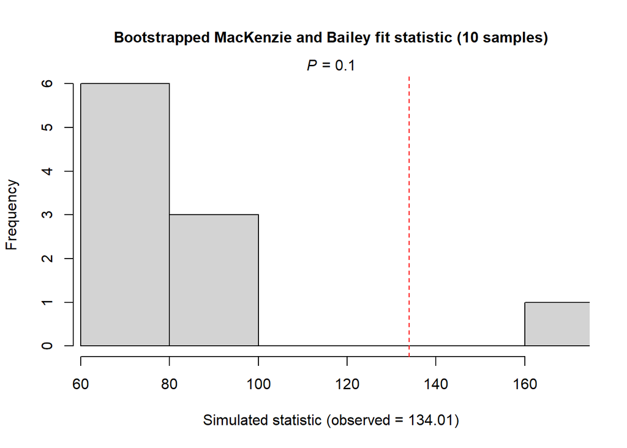

```r
print(mbgof)
```

```
##
## MacKenzie and Bailey goodness-of-fit for single-season occupancy model
##
## Pearson chi-square table:
##
##       Cohort Observed Expected Chi-square
## 00000      0       96   110.16       1.82
## 00100      0        1     0.49       0.52
## 00110      0        1     0.35       1.19
## 01000      0        2     1.24       0.47
## 01100      0        4     1.81       2.65
## 01110      0        1     1.39       0.11
## 01111      0        1     0.59       0.28
## 10000      0       11     3.08      20.36
## 10001      0        1     1.09       0.01
## 10010      0        1     2.19       0.64
## 10100      0        8     4.46       2.80
## 10101      0        1     1.70       0.29
## 10110      0        3     3.39       0.05
## 11000      0       17    11.22       2.98
## 11001      0        3     4.27       0.38
## 11010      0        2     8.52       4.99
## 11011      0        4     3.51       0.07
## 11100      0       18    17.40       0.02
## 11101      0        5     7.16       0.65
## 11110      0       12    14.20       0.34
## 11111      0       18     6.36      21.33
## 0000.      1       64    62.17       0.05
## 0011.      1        1     0.14       5.25
## 0110.      1        1     1.09       0.01
## 0111.      1        1     0.55       0.37
## 1000.      1        8     2.43      12.80
## 1001.      1        1     1.09       0.01
## 1010.      1        3     3.35       0.04
## 1011.      1        1     1.69       0.28
## 1100.      1        6     8.41       0.69
## 1101.      1        1     4.25       2.48
## 1110.      1        7    12.99       2.76
## 1111.      1       13     7.30       4.45
## 000..      2       40    35.44       0.59
```

[output cut: 20 more lines]

```
## ..000      8       15    10.18       2.29
## ..110      8        1     1.19       0.03
## ..111      8        1     0.53       0.41
## ..00.      9        1     0.65       0.19
## ...0.     10        1     0.98       0.00
##
## Chi-square statistic = 134.0109
## Number of bootstrap samples = 10
## P-value = 0.1
##
## Quantiles of bootstrapped statistics:
##   0%  25%  50%  75% 100%
##   63   70   74   93  170
##
## Estimate of c-hat = 1.55
```

We see that in both model validation fit statistics we achieve okay model support and we can proceed with model inference. But…we also notice that the c-hat is slightly higher than recommended.

### A quick note on potential overdispersion in occupancy models.

```r
## IF we detect over-dispersion...we can apply a correction for model selection using the code below
## Adjust by overdispersion (c-hat)
c_hat <- mbgof$c.hat.est

## We can use the overdispersion parameter from our model to adjust model selection criteria
## Note the c_hat argument taken from above
aictab(cand.set = list(fm1, fm2, fm3, fm4),
       c.hat = c_hat)
```

```
##
## Model selection based on QAICc:
## (c-hat estimate = 1.546041)
##
##       K   QAICc Delta_QAICc QAICcWt Cum.Wt Quasi.LL
## Mod4 12 1033.06        0.00       1      1  -504.21
## Mod3  6 1080.47       47.42       0      1  -534.15
## Mod2  5 1106.06       73.00       0      1  -547.97
## Mod1  3 1227.66      194.60       0      1  -610.81
```

```r
## We can use this to look at predictions with adjust SEs
## We would want to proceed with the adjusted responses for the best-fitting model
list(Unadj = summaryOD(fm4),
     Adj = summaryOD(fm4, c.hat = c_hat))
```

```
## $Unadj
##
## Precision unadjusted for overdispersion:
##
##                             Estimate Std. Error Lower 95% CL Upper 95% CL
## psi(Int)                    -0.40369    0.11018     -0.58493       -0.222
## psi(scale(utmn))            -0.23754    0.11697     -0.42994       -0.045
## psi(scale(topo_elev))        3.24175    0.76466      1.98400        4.499
## psi(scale(I(topo_elev^2)))  -2.72368    0.74027     -3.94131       -1.506
## psi(scale(ch_cfo_mn))       -0.90623    0.13103     -1.12176       -0.691
## p(Int)                       0.48048    0.09485      0.32447        0.636
## p(scale(eff.hrs))            0.24375    0.08728      0.10018        0.387
## p(scale(eff.jday))          -8.69033    3.84534    -15.01534       -2.365
## p(scale(I(eff.jday^2)))      7.58846    3.81589      1.31188       13.865
## p(scale(cc_cfo_mn))         -0.32417    0.09460     -0.47978       -0.169
## p(scale(topo_tpi))          -0.08486    0.08859     -0.23058        0.061
##
## (c-hat = 1)
##
##
## $Adj
##
## Precision adjusted for overdispersion:
##
##                             Estimate Std. Error Lower 95% CL Upper 95% CL
## psi(Int)                    -0.40369    0.13700     -0.62904       -0.178
## psi(scale(utmn))            -0.23754    0.14544     -0.47677        0.002
## psi(scale(topo_elev))        3.24175    0.95077      1.67787        4.806
## psi(scale(I(topo_elev^2)))  -2.72368    0.92045     -4.23768       -1.210
## psi(scale(ch_cfo_mn))       -0.90623    0.16292     -1.17422       -0.638
## p(Int)                       0.48048    0.11793      0.28650        0.674
## p(scale(eff.hrs))            0.24375    0.10853      0.06523        0.422
## p(scale(eff.jday))          -8.69033    4.78128    -16.55484       -0.826
## p(scale(I(eff.jday^2)))      7.58846    4.74467     -0.21583       15.393
## p(scale(cc_cfo_mn))         -0.32417    0.11763     -0.51765       -0.131
## p(scale(topo_tpi))          -0.08486    0.11016     -0.26605        0.096
##
## (c-hat = 1.546041)
```

## Visualizations

Below is code for plotting responses using output from our best-fitting model (Model 4) to visualize species occupancy and detection responses across predictors. We make use of two convenient functions from `unmarked`: `plotEffects` for quick visualizations and `plotEffectsData` to build some more customized plots. We will also use `unmarked`’s `predict` function with manually scaled covariates to exhibit how to go between scaled and original values on your marginal effects plots.

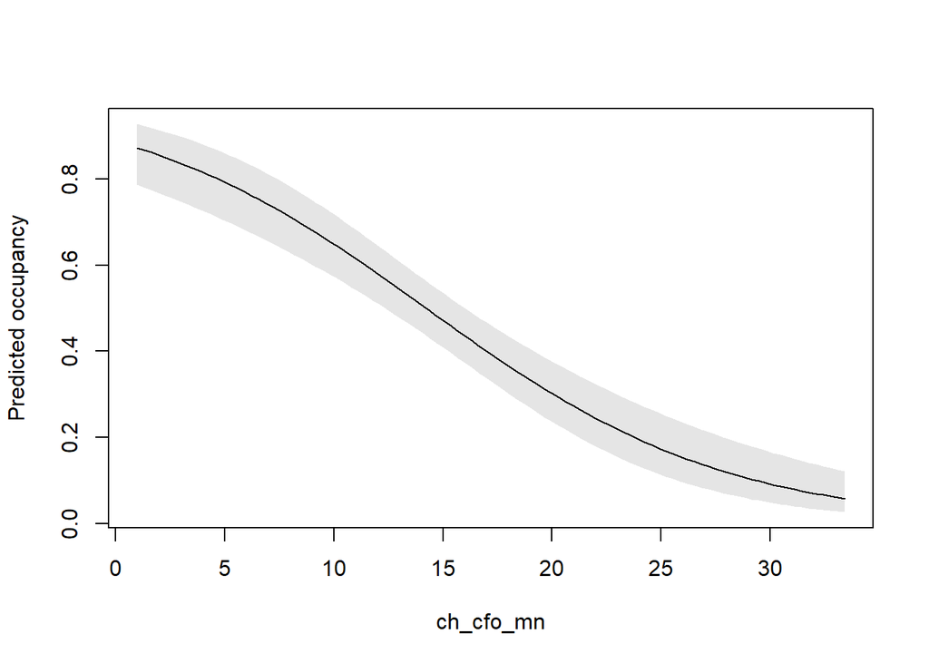

```r
## -------------------------------------------------------------
##
## Begin Section: Visualizations
##
## -------------------------------------------------------------

## Quick plotting via unmarked
## Works nicely for linear effects
suppressWarnings(plotEffects(fm4, "state", "ch_cfo_mn"))
```

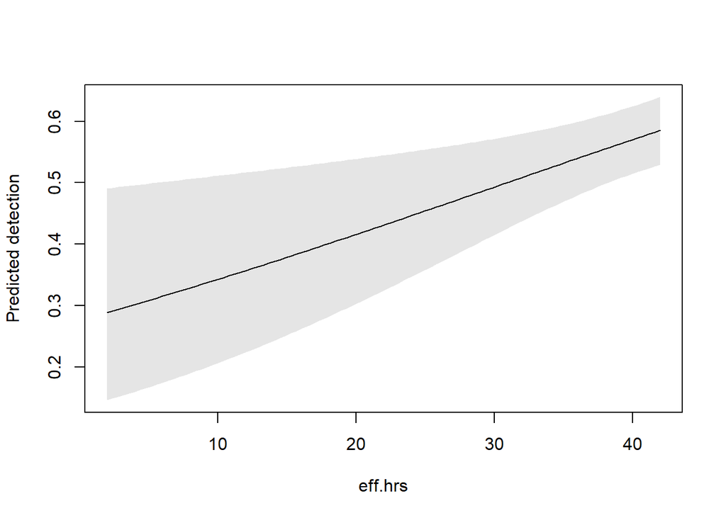

```r
suppressWarnings(plotEffects(fm4, "det", "eff.hrs"))
```

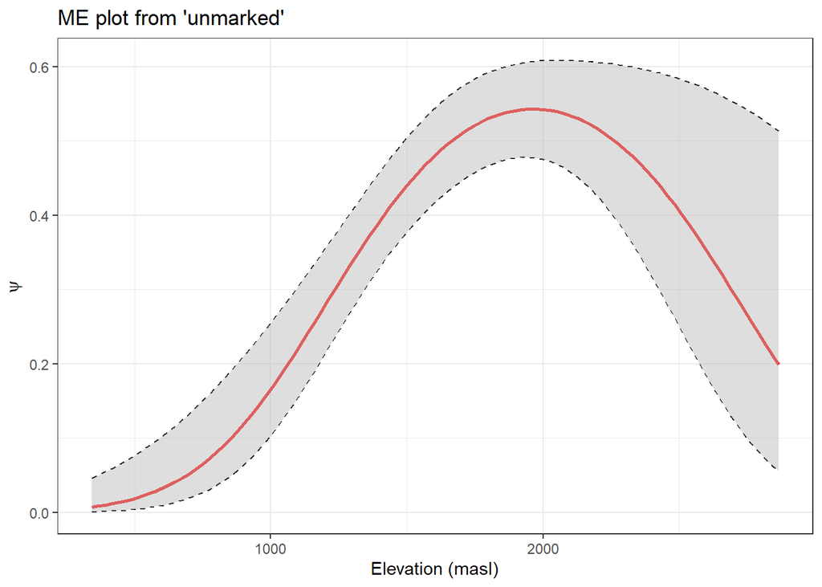

```r
## We can customize plots by extracting data using plotEffectsData
## You will likely see a warning about nested functions being
## improperly scaled...you might prefer to do manual scaling
## but as we see below the same plot is generated both ways
plot.df <- plotEffectsData(fm4, "state", "topo_elev")
ele.plot <- ggplot(data = plot.df, aes(x = covariateValue, y = Predicted)) +
  geom_line(linewidth = 1, color = "red") +
  geom_line(aes(x = covariateValue, y = upper), linetype = "dashed", color = "black") +
  geom_line(aes(x = covariateValue, y = lower), linetype = "dashed", color = "black") +
  geom_ribbon(aes(ymax = upper, ymin = lower), fill = "gray", alpha = 0.5) +
  theme_bw() +
  ylab(expression(psi)) +
  xlab("Elevation (masl)") +
  ggtitle("ME plot from 'unmarked'")

ele.plot
```

```r
## Example with manually scaled predictors to handle
## quadratic relationships

## Scale
mean.hr <- mean(obsCovs$eff.hrs, na.rm = T)
sd.hr <- sd(obsCovs$eff.hrs, na.rm = T)
obsCovs$eff.hrs.sc <- (obsCovs$eff.hrs - mean.hr) / sd.hr

mean.jday <- mean(obsCovs$eff.jday, na.rm = T)
sd.jday <- sd(obsCovs$eff.jday, na.rm = T)
obsCovs$eff.jday.sc <- (obsCovs$eff.jday - mean.jday) / sd.jday
obsCovs$eff.jday2.sc <- obsCovs$eff.jday.sc^2

mean.cc <- mean(siteCovs$cc_cfo_mn, na.rm = T)
sd.cc <- sd(siteCovs$cc_cfo_mn, na.rm = T)
siteCovs$cc_cfo_mn.sc <- (siteCovs$cc_cfo_mn - mean.cc) / sd.cc

mean.tpi <- mean(siteCovs$topo_tpi, na.rm = T)
sd.tpi <- sd(siteCovs$topo_tpi, na.rm = T)
siteCovs$topo_tpi.sc <- (siteCovs$topo_tpi - mean.tpi) / sd.tpi

## Can also use scale() function
siteCovs$utmn.sc <- as.numeric(scale(siteCovs$utmn))
siteCovs$topo_elev.sc <- as.numeric(scale(siteCovs$topo_elev))
siteCovs$topo_elev2.sc <- siteCovs$topo_elev.sc^2
siteCovs$ch_cfo_mn.sc <- as.numeric(scale(siteCovs$ch_cfo_mn))

## Repackage data
unmk2 <- unmarkedFrameOccu(y = y, siteCovs = siteCovs, obsCovs = obsCovs)
```

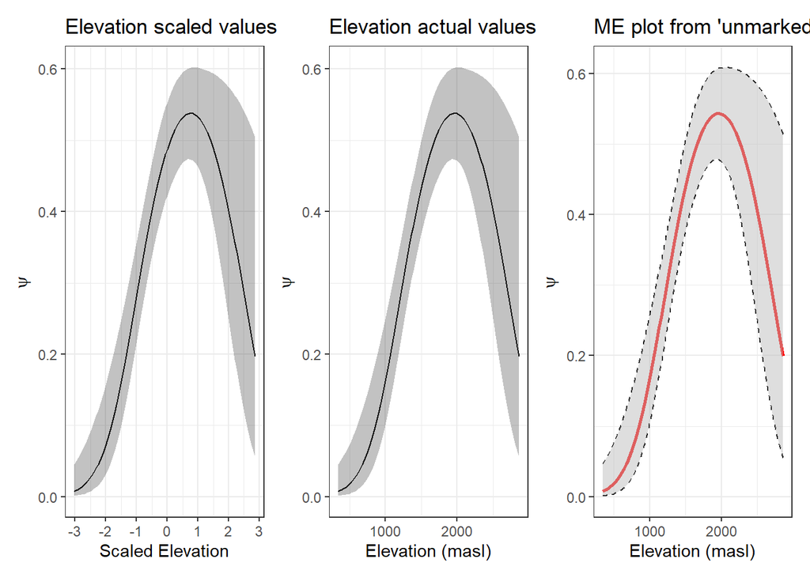

```r
## Fit the same model at fm4 with manually scaled covariates
fm5 <- occu(~ eff.hrs.sc +
              eff.jday.sc +
              eff.jday2.sc +
              cc_cfo_mn.sc +
              topo_tpi.sc
            ~ utmn.sc +
              topo_elev.sc +
              topo_elev2.sc +
              ch_cfo_mn.sc,
            data = unmk2)

## Do predictions by hand for elevational range
ele_range <- seq(min(unmk2@siteCovs$topo_elev.sc, na.rm=TRUE),
                  max(unmk2@siteCovs$topo_elev.sc, na.rm=TRUE),
                  length.out = 100)

## Make a new dataset to predict into
newdata <- data.frame(
  utmn.sc = mean(unmk2@siteCovs$utmn.sc, na.rm=TRUE),
  topo_elev.sc = ele_range,
  topo_elev2.sc = ele_range^2,
  ch_cfo_mn.sc = mean(unmk2@siteCovs$ch_cfo_mn.sc, na.rm=TRUE)
  )

## Predict occupancy
pred_occ <- predict(fm5, type="state", newdata=newdata, appendData=TRUE)

## Relationship on scaled units (x-axis)
ele.p1 <- ggplot(pred_occ, aes(x = topo_elev.sc, y = Predicted)) +
  geom_line() +
  geom_ribbon(aes(ymin = lower, ymax = upper), alpha = 0.3) +
  labs(x = "Scaled Elevation", y = expression(psi)) +
  theme_bw() +
  ggtitle("Elevation scaled values")

## Back-transform to original scale for plotting
mean.ele <- mean(siteCovs$topo_elev)
sd.ele <- sd(siteCovs$topo_elev)

pred_occ$topo_elev.orig <- pred_occ$topo_elev.sc * sd.ele + mean.ele

## Relationship on back-transformed (original) units
ele.p2 <- ggplot(pred_occ, aes(x = topo_elev.orig, y = Predicted)) +
  geom_line() +
  geom_ribbon(aes(ymin = lower, ymax = upper), alpha = 0.3) +
  labs(x = "Elevation (masl)", y = expression(psi)) +
  theme_bw() +
  ggtitle("Elevation actual values")

## Compare the plots for sanity
ele.p1 | ele.p2 | ele.plot
```

## Adding Complexity: False-positive single-season, single-species (static) occupancy model

Code below is for a false-positive flavor of occupancy model. Despite false-positive occupancy models being around for nearly 20 years they are still an active area of development. FP-models are also important for emerging bioacoustics pipelines with data derived from imperfect ML classifiers like (BirdNET) and detection thresholds. Given the rigidity of assumptions in standard occupancy models that there are zero FPs this extension is particularly relevant for all participants. However, these models are particularly tricky in lieu of extensive validation efforts and suffer from parameter identifiability issues. That is to say that it’s impossible for us to distinguish between scenarios in which $p_{11}$ (species detection and occupancy) and $p_{10}$ (species detection but doesn’t occupy; FP!) such that the model is multi-modal (Link and Royle, 2006). We can use some assumptions and numerical “tricks” to get the model to avoid sign switching but this is dependent on the species, acoustic quality, classifier performance, amount of validated data, and model structure. The models below correspond to a “Type 2” situation where we don’t have explicitly validated data with the acoustic detections. “Type 3” can improve parameter estimation and multi-modality by integrating “known” detections (e.g., expert listeners detect the species of interest). This data can then be integrated into the model as a multi-state model to help resolve the likelihood of an observation belonging to FP class vs TP class (Miller et al. 2011) and for bioacoustics specifically see Chambert et al. (2018). See Royle and Link (2006), Miller et al. (2011), Chambert et al. (2018), and Rhinehart et al. (2023), Kery and Royle (2023; Chapter 7 Volume 2) for additional readings.

```r
## ~~~~~~~~~~~~~~~~~~~~~~~~~~~~~~~~~~~~~~~~~~~~~~~~~~~~~~~~~~~~~
##
## Subsection: False-positive models
##
## ~~~~~~~~~~~~~~~~~~~~~~~~~~~~~~~~~~~~~~~~~~~~~~~~~~~~~~~~~~~~~

## Adding species richness as an indicator for potentially "noisy" environments
## Can you think of other indicators to provide the model to help delineate
## FPs? What might they be?
rich <- occ.dat$y
rich <- apply(rich, c(1,2), sum)
rich <- rich[subARU,]

## We assume all data can be impacted by FP
type <- c(0,5,0)
obsCovsFP <- list(eff.hrs = obsCovs$eff.hrs,
                eff.jday = obsCovs$eff.jday,
                rich = rich,
                METH = y)
unmk.fp <- unmarkedFrameOccuFP(y = y, siteCovs = siteCovs, obsCovs = obsCovsFP, type = type)
class(unmk.fp)
```

```
## [1] "unmarkedFrameOccuFP"
## attr(,"package")
## [1] "unmarked"
```

```r
summary(unmk.fp)
```

```
## unmarkedFrame Object
##
## 500 sites
## Maximum number of observations per site: 5
## Mean number of observations per site: 4.15
## Sites with at least one detection: 211
##
## Tabulation of y observations:
##    0    1 <NA>
## 1501  576  423
##
## Site-level covariates:
##     Cell_Unit        utme             utmn           topo_elev
##  C0001_U3:  1   Min.   :236380   Min.   :3916783   Min.   : 343
##  C0004_U2:  1   1st Qu.:324703   1st Qu.:4150508   1st Qu.:1343
##  C0006_U2:  1   Median :653832   Median :4308760   Median :1650
##  C0011_U3:  1   Mean   :549335   Mean   :4278410   Mean   :1639
##  C0012_U1:  1   3rd Qu.:699119   3rd Qu.:4406986   3rd Qu.:1942
##  C0027_U2:  1   Max.   :763607   Max.   :4522081   Max.   :2865
##  (Other) :494
##     topo_tpi            tmx_bcm_mn      ppt_bcm_mn     fire1_5yr_cbi_mn
##  Min.   :-0.3153539   Min.   :10.50   Min.   : 322.4   Min.   :0.0000
##  1st Qu.:-0.0330124   1st Qu.:14.54   1st Qu.:1013.0   1st Qu.:0.0000
##  Median : 0.0001365   Median :16.09   Median :1192.8   Median :0.0000
##  Mean   : 0.0045990   Mean   :16.41   Mean   :1291.0   Mean   :0.2615
##  3rd Qu.: 0.0439829   3rd Qu.:18.28   3rd Qu.:1599.7   3rd Qu.:0.0000
##  Max.   : 0.2332589   Max.   :24.79   Max.   :2537.9   Max.   :2.9657
##
##  fire6_10yr_cbi_mn fire11_35yr_cbi_mn fire1_5yr_high_prop fire1_5yr_lowmod_prop
##  Min.   :0.0000    Min.   :0.0000     Min.   :0.00000     Min.   :0.00000
##  1st Qu.:0.0000    1st Qu.:0.0000     1st Qu.:0.00000     1st Qu.:0.00000
##  Median :0.0000    Median :0.0000     Median :0.00000     Median :0.00000
##  Mean   :0.2094    Mean   :0.1832     Mean   :0.06417     Mean   :0.06471
##  3rd Qu.:0.0000    3rd Qu.:0.0000     3rd Qu.:0.00000     3rd Qu.:0.00000
##  Max.   :2.7900    Max.   :2.7388     Max.   :1.00000     Max.   :1.00000
##
##  fire6_10yr_high_prop fire6_10yr_lowmod_prop fire11_35yr_high_prop
##  Min.   :0.00000      Min.   :0.000          Min.   :0.00000
##  1st Qu.:0.00000      1st Qu.:0.000          1st Qu.:0.00000
##  Median :0.00000      Median :0.000          Median :0.00000
```

[output cut: 31 more lines]

```
##  Median :0.49795   Median :-0.07561
##  Mean   :0.99800   Mean   : 0.00000
##  3rd Qu.:1.32856   3rd Qu.: 0.66422
##  Max.   :9.13075   Max.   : 2.98068
##
##
## Observation-level covariates:
##     eff.hrs         eff.jday          rich            METH
##  Min.   : 2.00   Min.   :154.5   Min.   : 0.00   Min.   :0.0000
##  1st Qu.:42.00   1st Qu.:160.5   1st Qu.:16.00   1st Qu.:0.0000
##  Median :42.00   Median :166.5   Median :19.00   Median :0.0000
##  Mean   :38.39   Mean   :165.8   Mean   :18.88   Mean   :0.2773
##  3rd Qu.:42.00   3rd Qu.:172.5   3rd Qu.:22.00   3rd Qu.:1.0000
##  Max.   :42.00   Max.   :178.5   Max.   :35.00   Max.   :1.0000
##  NA's   :423     NA's   :423     NA's   :423     NA's   :423
```

```r
## We add starting values to try to avoid incorrect modality
## We state that p11 >> p10 (i.e., FP should be quite small)
largerp11_int <- qlogis(c(0.5, ## Occupancy prob
                      0.7, ## Detection prob
                      0.1  ## FP
                      ))
largerp11 <- qlogis(c(0.5, 0.5, 0.5, 0.5, 0.5, #occupancy (int + covs)
                      0.7, 0.5, 0.5, 0.5, 0.5, #detection (int + covs)
                      0.1, 0.5 #fp (int + covs)
                      ))

fm5 <- occuFP(detformula = ~1,
              stateformula = ~1,
              FPformula = ~1,
              data = unmk.fp,
              starts = largerp11_int)

fm6 <- occuFP(detformula = ~scale(eff.hrs) + scale(eff.jday) + scale(I(eff.jday^2)) + scale(cc_cfo_mn),
              stateformula = ~scale(utmn) + scale(topo_elev) + scale(I(topo_elev^2)) + scale(ch_cfo_mn),
              FPformula = ~scale(rich),
              data = unmk.fp,
              starts = largerp11)

fm6
```

```
##
## Call:
## occuFP(detformula = ~scale(eff.hrs) + scale(eff.jday) + scale(I(eff.jday^2)) +
##     scale(cc_cfo_mn), FPformula = ~scale(rich), stateformula = ~scale(utmn) +
##     scale(topo_elev) + scale(I(topo_elev^2)) + scale(ch_cfo_mn),
##     data = unmk.fp, starts = largerp11)
##
## Occupancy (logit-scale):
##                       Estimate    SE     z  P(>|z|)
## (Intercept)             -0.423 0.118 -3.60 3.20e-04
## scale(utmn)             -0.240 0.118 -2.05 4.08e-02
## scale(topo_elev)         3.269 0.773  4.23 2.37e-05
## scale(I(topo_elev^2))   -2.743 0.747 -3.67 2.40e-04
## scale(ch_cfo_mn)        -0.908 0.132 -6.87 6.53e-12
##
## Detection (logit-scale):
##                      Estimate     SE     z  P(>|z|)
## (Intercept)             0.492 0.1027  4.79 1.68e-06
## scale(eff.hrs)          0.247 0.0875  2.83 4.73e-03
## scale(eff.jday)        -8.595 3.8910 -2.21 2.72e-02
## scale(I(eff.jday^2))    7.495 3.8612  1.94 5.23e-02
## scale(cc_cfo_mn)       -0.320 0.0971 -3.29 9.95e-04
##
## false positive (logit-scale):
##             Estimate   SE     z P(>|z|)
## (Intercept)    -7.46 3.03 -2.46  0.0139
## scale(rich)     1.85 1.44  1.28  0.1990
##
## AIC: 1583.65
## Number of sites: 500
```

```r
## False-positive rate confidence
unmarked::confint(fm6, type = "fp")
```

```
##                       0.025     0.975
## fp(Int)         -13.4086621 -1.513077
## fp(scale(rich))  -0.9713169  4.665538
```

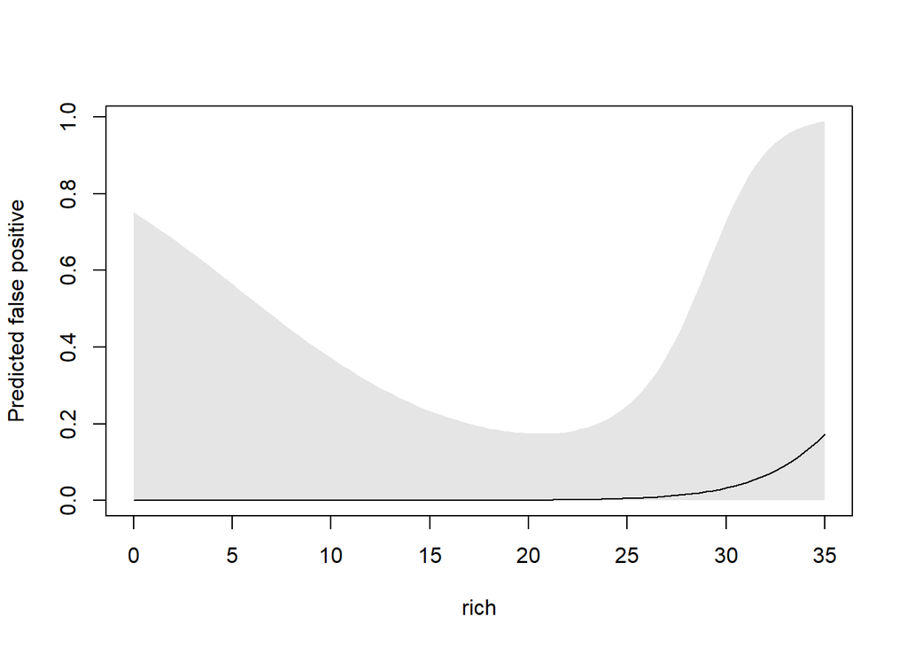

```r
fp_coef <- plogis(coef(fm6))[grep("^fp", names(plogis(coef(fm6))))]

## Quick Visualization
plotEffects(fm6, type = "fp", covariate = "rich")
```

## Adding Complexity: Multi-species, static occupancy model

Multi-species occupancy models (MSOMs) are a great tool for estimating imperfect detection-corrected estimates of communities and for downstream biodiversity analyses (see Iknayan et al. (2014); Jarzyna and Jetz (2016)). Below is the code and set up for an MSOM across five species (for simplicity) in the Sierra Nevada: [Acorn Woodpecker](https://birdsoftheworld.org/bow/species/acowoo/cur/introduction), [Hermit Warbler](https://birdsoftheworld.org/bow/species/herwar/cur/introduction), [Golden-crowned Kinglet](https://birdsoftheworld.org/bow/species/gockin/cur/introduction), [Lazuli Bunting](https://birdsoftheworld.org/bow/species/lazbun/cur/introduction), and [Olive-sided Flycatcher](https://birdsoftheworld.org/bow/species/olsfly/cur/introduction). It is feasible to run five separate occupancy models across this assemblage by looping over each species individually but running species in a MSOM framework provides some advantages:

1. Improved coefficient precision for rare species from information borrowing
2. Propagation of errors in community-level estimates
3. Potential for data augmentation to estimate latent meta-community (species never detected; e.g., Dorazio and Royle (2005); Zipkin et al. (2010))

Expanding our formulas above from a single-species static occupancy model to a multi-species static occupancy model with covariates looks like such:
$$z_{ik} \sim Bernoulli(\psi_{ik}) \\
y_{ijk} \sim Bernoulli(z_{ik} * p_{ijk}) \\
logit(\psi_{ik}) = \beta_{0,k} + \beta_{1,ik} * X_{1,i} + \beta_{n,ik} *
X_{n,i} \\
logit(p_{ik}) = \alpha_{0,k} + \alpha_{1,ijk} * X_{1,ij} +
\alpha_{n,ijk} * X_{n,ij} \\
\beta_{0,k} \sim Normal(\mu_{\beta_0}, \sigma_{\beta_0}) \\
\beta_{1,k} \sim Normal(\mu_{\beta_1}, \sigma_{\beta_1}) \\
\beta_{n,k} \sim Normal(\mu_{\beta_n}, \sigma_{\beta_n}) \\
\alpha_{0,k} \sim Normal(\mu_{\alpha_0}, \sigma_{\alpha_0}) \\
\alpha_{1,k} \sim Normal(\mu_{\alpha_1}, \sigma_{\alpha_1}) \\
\alpha_{n,k} \sim Normal(\mu_{\alpha_n}, \sigma_{\alpha_n}) \\$$
The key difference is that species intercepts and slopes are expected to arise from a $Normal$ distribution. Thus, for rare species we can leverage this structure to “borrow” information from more common species such that these rare species tend to approach the mean values estimated for the community from the model above. This is commonly referred to as “information borrowing” or “partial pooling” and “Bayesian shrinkage” in a Bayesian context. From this model structure we can estimate individual species responses in detection and occupancy but also the average community-wide response.

```r
## -------------------------------------------------------------
##
## Begin Section: Single-season, multi-species version
##
## -------------------------------------------------------------

## We call the observations of all 86 species from before
dimnames(y.all)
```

```
## $sites
##   [1] "C0165_U1" "C6110_U1" "C6385_U1" "C0281_U1" "C3447_U2" "C3408_U2"
##   [7] "C4468_U2" "C7080_U1" "C0079_U2" "C0301_U2" "C5227_U2" "C0076_U1"
##  [13] "C5726_U2" "C7249_U1" "C0256_U3" "C0134_U1" "C2054_U2" "C0173_U2"
##  [19] "C7660_U2" "C0348_U2" "C5659_U1" "C0177_U2" "C2101_U1" "C3184_U2"
##  [25] "C7828_U1" "C4651_U2" "C6308_U1" "C0201_U2" "C2275_U1" "C3056_U1"
##  [31] "C5698_U2" "C0233_U2" "C0133_U1" "C5992_U1" "C3772_U2" "C0224_U2"
##  [37] "C3210_U1" "C1943_U1" "C0113_U1" "C0189_U3" "C2011_U2" "C7798_U1"
##  [43] "C6939_U1" "C8135_U2" "C2038_U2" "C7803_U2" "C0056_U2" "C5427_U2"
##  [49] "C2726_U1" "C3513_U1" "C2203_U2" "C0001_U3" "C8072_U1" "C2437_U2"
##  [55] "C0138_U1" "C0031_U3" "C8065_U2" "C4796_U1" "C6309_U2" "C3571_U1"
##  [61] "C0218_U3" "C7179_U1" "C5693_U2" "C5614_U2" "C2091_U2" "C0269_U1"
##  [67] "C7023_U1" "C3382_U2" "C3457_U2" "C0321_U1" "C7193_U1" "C2702_U1"
##  [73] "C4979_U2" "C0161_U1" "C4422_U1" "C0064_U3" "C2352_U2" "C0031_U1"
##  [79] "C2616_U2" "C5064_U1" "C2836_U1" "C3242_U2" "C3396_U1" "C5366_U1"
```

[output cut: 118 more lines]

```r
## We subset these to a few species
spoi <- c("Acorn Woodpecker",
          "Hermit Warbler",
          "Golden-crowned Kinglet",
          "Lazuli Bunting",
          "Olive-sided Flycatcher")

## Subset the 3-d array
sp.ind <- which(dimnames(y.all)[[3]] %in% spoi)

## Break the data apart for demonstration purposes
y.msom <- y.all[,,sp.ind] # Take species of interest

## y.msom is expected to be formatted M x J x S (Sites x Reps x Species)
## We can use aperm to reorder
#y.msom <- aperm(y.msom, c(2, 3, 1))

## Package these elements into an unmarked object
unmk.comm <- unmarkedFrameOccuComm(y = y.msom, siteCovs = siteCovs, obsCovs = obsCovs, speciesCovs = NULL)
class(unmk.comm)
```

```
## [1] "unmarkedFrameOccuComm"
## attr(,"package")
## [1] "unmarked"
```

```r
## Let's test the same best fitting model from above
fm7 <- occuComm(~ scale(eff.hrs) + scale(eff.jday) ~ scale(topo_elev), data = unmk.comm)
## Inspect the model
fm7
```

```
##
## Call:
## occuComm(formula = ~scale(eff.hrs) + scale(eff.jday) ~ scale(topo_elev),
##     data = unmk.comm)
##
## Occupancy (logit-scale):
## Random effects:
##   Groups             Name Variance Std.Dev.
##  species      (Intercept)    1.683    1.297
##  species scale(topo_elev)    0.663    0.814
##
## Fixed effects:
##                  Estimate    SE      z P(>|z|)
## (Intercept)        -0.242 0.583 -0.415   0.678
## scale(topo_elev)   -0.096 0.368 -0.260   0.795
##
## Detection (logit-scale):
## Random effects:
##   Groups            Name Variance Std.Dev.
##  species     (Intercept)    0.074    0.272
##  species  scale(eff.hrs)    0.000    0.000
##  species scale(eff.jday)    0.109    0.330
##
## Fixed effects:
##                 Estimate     SE     z  P(>|z|)
## (Intercept)        1.356 0.1292 10.50 8.86e-26
## scale(eff.hrs)     0.316 0.0323  9.78 1.33e-22
## scale(eff.jday)   -0.225 0.1537 -1.47 1.42e-01
##
## AIC: 7651.579
## Number of species: 5
## Number of sites: 500
```

```r
## We can still do AIC model selection for the multi-species models
## Add a polynomial term for the elevation in a slightly more complex model form
fm8 <- occuComm(~ scale(eff.hrs) + scale(eff.jday) ~ scale(topo_elev) + scale(I(topo_elev^2)), data = unmk.comm)
```

We see that the only predictor that has a significant impact at the community scale is the number of effort hours that an ARU was active, this is accompanied by a very small estimated variance suggesting all species respond very similarly. Converesly, the community does not exhibit a consistent effect in response to elevation in the occupancy submodel or ordinal date in the detection model. However, this community-wide patterns can mask individual species responses. Let’s look at this for elevation…

We can extract the random effects (intercepts and slopes) from our MSOM in `unmarked` using the `randomTerms` argument.

```r
## Look at species-specific random intercepts and slopes
## These estimates are drawn from a normal distribution
## with mean zero which tells you the deviation for each
## species from the averagae
rt <- randomTerms(fm8)
rt
```

```
##    Model  Groups                  Name                  Level      Estimate
## 1    psi species           (Intercept)       Acorn Woodpecker -2.302668e+00
## 2    psi species           (Intercept) Golden-crowned Kinglet  9.219312e-01
## 3    psi species           (Intercept)         Hermit Warbler  9.996359e-01
## 4    psi species           (Intercept)         Lazuli Bunting -7.505176e-01
## 5    psi species           (Intercept) Olive-sided Flycatcher  1.155380e+00
## 6    psi species      scale(topo_elev)       Acorn Woodpecker -1.382605e+00
## 7    psi species      scale(topo_elev) Golden-crowned Kinglet  6.094515e-01
## 8    psi species      scale(topo_elev)         Hermit Warbler  1.751026e+00
## 9    psi species      scale(topo_elev)         Lazuli Bunting -6.119900e-02
## 10   psi species      scale(topo_elev) Olive-sided Flycatcher -9.572762e-01
## 11   psi species scale(I(topo_elev^2))       Acorn Woodpecker -2.292251e-01
## 12   psi species scale(I(topo_elev^2)) Golden-crowned Kinglet  3.469846e-01
## 13   psi species scale(I(topo_elev^2))         Hermit Warbler -1.754394e+00
## 14   psi species scale(I(topo_elev^2))         Lazuli Bunting  1.276078e-02
```

[output cut: 47 more lines]

```r
## We can add in the "fixed" part of the model to get
## a more complete picture using the argument
## addMean = TRUE to show us the full response
rtmean <- randomTerms(fm8, addMean = TRUE)
rtmean
```

```
##    Model  Groups                  Name                  Level    Estimate
## 1    psi species           (Intercept)       Acorn Woodpecker -2.57700873
## 2    psi species           (Intercept) Golden-crowned Kinglet  0.64759091
## 3    psi species           (Intercept)         Hermit Warbler  0.72529564
## 4    psi species           (Intercept)         Lazuli Bunting -1.02485783
## 5    psi species           (Intercept) Olive-sided Flycatcher  0.88103945
## 6    psi species      scale(topo_elev)       Acorn Woodpecker -0.63436190
## 7    psi species      scale(topo_elev) Golden-crowned Kinglet  1.35769501
## 8    psi species      scale(topo_elev)         Hermit Warbler  2.49926931
## 9    psi species      scale(topo_elev)         Lazuli Bunting  0.68704447
## 10   psi species      scale(topo_elev) Olive-sided Flycatcher -0.20903276
## 11   psi species scale(I(topo_elev^2))       Acorn Woodpecker -1.13290903
## 12   psi species scale(I(topo_elev^2)) Golden-crowned Kinglet -0.55669927
## 13   psi species scale(I(topo_elev^2))         Hermit Warbler -2.65807797
## 14   psi species scale(I(topo_elev^2))         Lazuli Bunting -0.89092311
```

[output cut: 47 more lines]

```r
## We can look at occupancy using the predict function
## In this case we gave the model no newdata so it
## predicts at each location conditional on the
## covariates there
lapply(predict(fm8, type = "state"), head)
```

```
## $`Acorn Woodpecker`
##    Predicted          SE       lower      upper
## 1 0.29502305 0.033862057 0.233220595 0.36539846
## 2 0.14831965 0.021631295 0.110714129 0.19588481
## 3 0.15670567 0.022363297 0.117675682 0.20566345
## 4 0.03506512 0.010584644 0.019303408 0.06287159
## 5 0.02230273 0.008493170 0.010520046 0.04665996
## 6 0.01100110 0.005795787 0.003900411 0.03063107
##
## $`Golden-crowned Kinglet`
##   Predicted         SE     lower     upper
## 1 0.4693757 0.03380001 0.4040458 0.5357724
## 2 0.5951827 0.02870851 0.5379019 0.6499834
## 3 0.5868823 0.02896077 0.5292103 0.6422651
## 4 0.7487478 0.02402889 0.6988024 0.7928660
## 5 0.7797839 0.02418927 0.7287559 0.8235368
## 6 0.8181193 0.02655804 0.7602116 0.8645345
##
## $`Hermit Warbler`
##   Predicted         SE     lower     upper
## 1 0.7079824 0.02828560 0.6496390 0.7601966
## 2 0.7448403 0.02455630 0.6938198 0.7899331
## 3 0.7437098 0.02461195 0.6925909 0.7889189
## 4 0.7153650 0.02531576 0.6632707 0.7622885
## 5 0.6873123 0.02686857 0.6324052 0.7374233
## 6 0.6264407 0.03330075 0.5592376 0.6890939
##
## $`Lazuli Bunting`
##   Predicted         SE     lower     upper
## 1 0.3044972 0.02971392 0.2495585 0.3656377
## 2 0.2997546 0.02595507 0.2514634 0.3529470
## 3 0.3005919 0.02609626 0.2520389 0.3540706
## 4 0.2627190 0.02423319 0.2180457 0.3128828
## 5 0.2473103 0.02517142 0.2013238 0.2998573
## 6 0.2214653 0.02893396 0.1699397 0.2832816
##
## $`Olive-sided Flycatcher`
##   Predicted         SE     lower     upper
## 1 0.5822261 0.03257851 0.5173451 0.6443807
## 2 0.6389580 0.02908578 0.5802330 0.6938030
## 3 0.6345761 0.02927696 0.5755290 0.6898360
## 4 0.7456704 0.02457848 0.6945839 0.7907856
## 5 0.7755836 0.02515304 0.7224951 0.8210317
## 6 0.8181853 0.02841609 0.7557844 0.8674385
```

```r
## The mean occupancy across all sites for each species
lapply(predict(fm8, type = "state"), function(x) mean(x$Predicted))
```

```
## $`Acorn Woodpecker`
## [1] 0.147642
##
## $`Golden-crowned Kinglet`
## [1] 0.6410035
##
## $`Hermit Warbler`
## [1] 0.6694031
##
## $`Lazuli Bunting`
## [1] 0.2668966
##
## $`Olive-sided Flycatcher`
## [1] 0.6933998
```

```r
## Detection
lapply(predict(fm8, type = "det"), function(x) mean(x$Predicted, na.rm = T))
```

```
## $`Acorn Woodpecker`
## [1] 0.7967893
##
## $`Golden-crowned Kinglet`
## [1] 0.8352109
##
## $`Hermit Warbler`
## [1] 0.7946693
##
## $`Lazuli Bunting`
## [1] 0.7165468
##
## $`Olive-sided Flycatcher`
## [1] 0.7596159
```

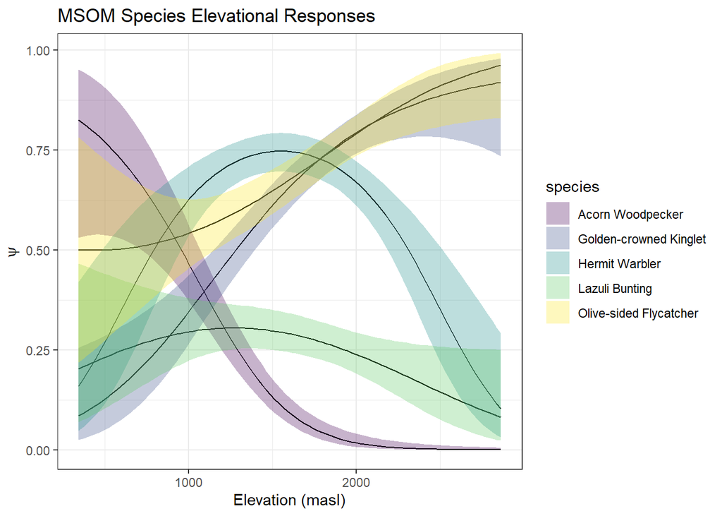

```r
## Make the manual range for the predictor
ele_range <- range(siteCovs(unmk.comm)$topo_elev)
ele_seq <- seq(ele_range[1], ele_range[2], length.out = 100)

## Set the number of species
nspec <- 5

## Make a new df
newdata <- data.frame(topo_elev = rep(ele_seq, nspec),
                      species = rep(spoi,
                                    each = 100))

## Predict the modelled effects
occ_msom <- suppressWarnings(predict(fm8, type = "state", newdata = newdata, appendData = T))

## Plot the species-specific marginal effects layered
ggplot(occ_msom, aes(x = topo_elev, y = Predicted, fill = species)) +
  geom_line() +
  geom_ribbon(aes(ymin = lower, ymax = upper), alpha = 0.3) +
  scale_fill_viridis_d() +
  labs(x = "Elevation (masl)", y = expression(psi)) +
  theme_bw() +
  ggtitle("MSOM Species Elevational Responses")
```

Model selection for MSOMs follow a similar strategy from what we saw above. Below is a function that estimates similar AIC model output from the `modSel` function provided by `unmarked`, which at the time of writing this tutorial doesn’t handle model objects from community occupancy models. However, a more robust alternative would be to use `aictab` from the `aicmodAvg` package we used above. What are some other hypotheses we can test in a multi-species framework that might be interesting?

```r
fm7@AIC > fm8@AIC
```

```
## [1] TRUE
```

```r
(fm7@AIC - fm8@AIC) > 4
```

```
## [1] TRUE
```

```r
## We can extract the AICs and calculate AIC weights with something like this
AICweight <- function(models){
  if(is.null(names(models))){
    mod_names <- paste("Model ", seq(1,length(models)))
  } else {
    mod_names <- names(models)
  }
  aics <- unlist(lapply(models, function(x) x@AIC))
  minAIC <- min(aics)
  delta.aic <- aics - minAIC
  weight <- exp((-1 * delta.aic)/2) / sum(exp((-1 * delta.aic)/2))
  weight <- data.frame(Model = mod_names, AIC = aics, DeltaAIC = delta.aic, AICweight = round(weight, 3))
  rownames(weight) <- NULL
  return(weight)
}

## Overall model selection - would be interesting to see if this is the case for individual species models too!
AICweight(models = list("Elev" = fm7, "Elev Sq" = fm8))
```

```
##     Model      AIC DeltaAIC AICweight
## 1    Elev 7651.579 22.73136         0
## 2 Elev Sq 7628.848  0.00000         1
```

```r
## Alternative way for model selection
aictab(cand.set = list(fm7,
                       fm8),
       modnames = c("Ele Lin", "Ele Poly"))
```

```
##
## Model selection based on AICc:
##
##           K    AICc Delta_AICc AICcWt Cum.Wt       LL
## Ele Poly 12 7629.49       0.00      1      1 -3802.42
## Ele Lin  10 7652.03      22.54      0      1 -3815.79
```

```r
# ## Compare Naive to Estimated
# ## We can see some of the issues with diversity estimates
# ## without accounting for imperfect detection...
# ## Some sites have lower observed richness than expected!
# ## This problem might become more extreme with more species
# ## and rare species
# ## We can get richness values from this model
r <- richness(fm8, posterior = T) ## posterior = T gets us uncertainty
```

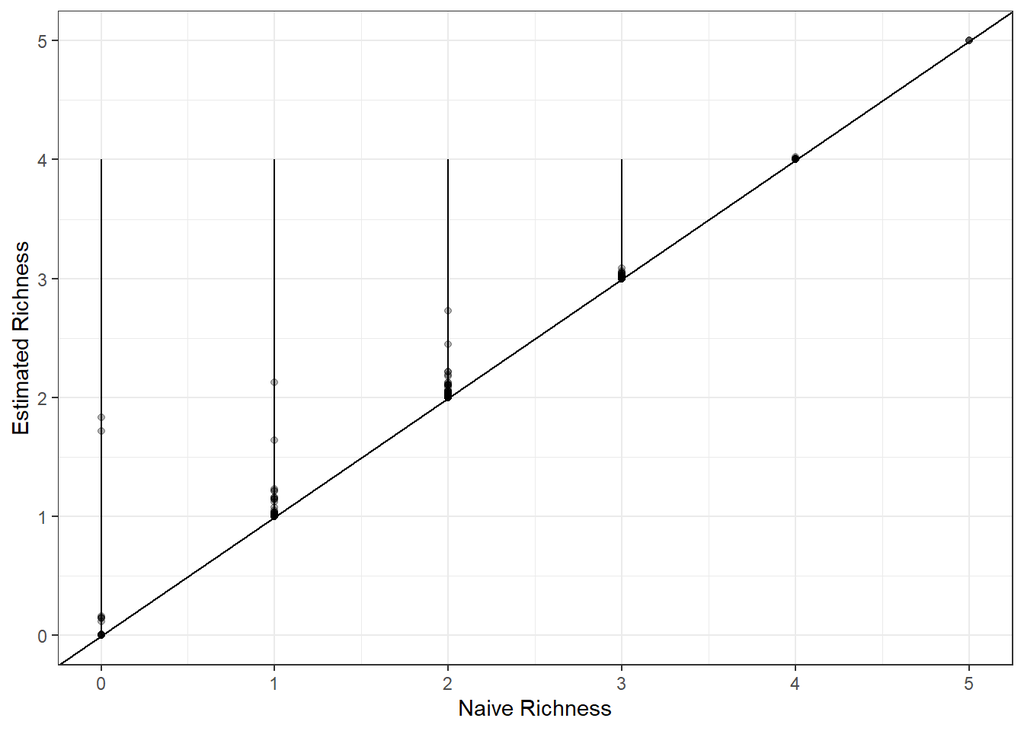

```r
est <- apply(r@samples, 1, mean)
low <- apply(r@samples, 1, quantile, 0.025)
high <- apply(r@samples, 1, quantile, 0.975)


naive.rich <- apply(apply(y.msom, c(1,3), function(x) if(all(is.na(x))) return(NA) else return(max(x, na.rm = T))), 1, sum, na.rm = T)

rich.df <- data.frame(Naive = naive.rich, Estimated = est, Low = low, High = high)

ggplot(data = rich.df, aes(x = Naive, y = Estimated)) +
  geom_point(alpha = 0.3) +
  geom_linerange(aes(ymin = Low, ymax = High)) +
  geom_abline(slope = 1, intercept = 0) +
  theme_bw() +
  ylab("Estimated Richness") +
  xlab("Naive Richness")
```

```r
re <- ranef(fm8)
z_mat <- lapply(re, function(x) bup(x, stat = "mode"))

## Z-mat back to community mat
## Now you have a detection-corrected community and
## you can perform a number of community-based analyses
z_arr <- abind::abind(z_mat, along = 2)
head(z_arr)
```

```
##      Acorn Woodpecker Golden-crowned Kinglet Hermit Warbler Lazuli Bunting
## [1,]                0                      0              0              1
## [2,]                1                      0              0              1
## [3,]                1                      1              0              1
## [4,]                0                      1              0              1
## [5,]                0                      1              1              0
## [6,]                0                      1              1              0
##      Olive-sided Flycatcher
## [1,]                      1
## [2,]                      1
## [3,]                      1
## [4,]                      1
## [5,]                      1
## [6,]                      1
```

Brunk, K. M., R. J. Gutiérrez, M. Z. Peery, C. A. Cansler, S. Kahl, and C. M. Wood. 2023. [Quail on fire: Changing fire regimes may benefit mountain quail in fire-adapted forests](https://doi.org/10.1186/s42408-023-00180-9). Fire Ecology 19:19.

Chambert, T., J. H. Waddle, D. A. W. Miller, S. C. Walls, and J. D. Nichols. 2018. [A new framework for analysing automated acoustic species detection data: Occupancy estimation and optimization of recordings post-processing](https://doi.org/10.1111/2041-210X.12910). Methods in Ecology and Evolution 9:560–570.

Dorazio, R. M., and J. A. Royle. 2005. [Estimating Size and Composition of Biological Communities by Modeling the Occurrence of Species](https://doi.org/10.1198/016214505000000015). Journal of the American Statistical Association 100:389–398.

Fiske, I., and R. Chandler. 2011. [**Unmarked** : An *r* Package for Fitting Hierarchical Models of Wildlife Occurrence and Abundance](https://doi.org/10.18637/jss.v043.i10). J. Stat. Soft. 43.

Iknayan, K. J., M. W. Tingley, B. J. Furnas, and S. R. Beissinger. 2014. [Detecting diversity: Emerging methods to estimate species diversity](https://doi.org/10.1016/j.tree.2013.10.012). Trends in Ecology & Evolution 29:97–106.

Jarzyna, M. A., and W. Jetz. 2016. [Detecting the Multiple Facets of Biodiversity](https://doi.org/10.1016/j.tree.2016.04.002). Trends in Ecology & Evolution 31:527–538.

Kellner, K. F., A. D. Smith, J. A. Royle, M. Kéry, J. L. Belant, and R. B. Chandler. 2023. [The unmarked R package: Twelve years of advances in occurrence and abundance modelling in ecology](https://doi.org/10.1111/2041-210X.14123). Methods Ecol Evol 14:1408–1415.

MacKenzie, D. I., and L. L. Bailey. 2004. [Assessing the fit of site-occupancy models](https://doi.org/10.1198/108571104X3361). JABES 9:300–318.

Miller, D. A., J. D. Nichols, B. T. McClintock, E. H. C. Grant, L. L. Bailey, and L. A. Weir. 2011. [Improving occupancy estimation when two types of observational error occur: Non-detection and species misidentification](https://doi.org/10.1890/10-1396.1). Ecology 92:1422–1428.

Royle, J. A., and W. A. Link. 2006. Generalized Site Occupancy Models Allowing for False Positive and False Negative Errors. Ecology 87:835–841.

Zipkin, E. F., J. Andrew Royle, D. K. Dawson, and S. Bates. 2010. [Multi-species occurrence models to evaluate the effects of conservation and management actions](https://doi.org/10.1016/j.biocon.2009.11.016). Biological Conservation 143:479–484.